# Part II - Correlation among OriginalLoanAmount, ProsperRating and BorrowerAPR and the influence of BorrowerAPR, LenderYield on LoanStatus

## by Maximilien Kpizingui

## Investigation Overview

In this slide deck we are going to explore the correlation of the Original Loan Amount, ProsperRating on the BorrowerAPR. Besides, we will figure out how the BorrowerAPR and LenderYield may affect the loan status.

## Dataset Overview

ProsperLoan dataset subjected to our analysis contains 113,937 observations and 81 features.Among these observations, we found that there were 1364086 missing values and some features which were not of interest in our analysis were also dropped. The wrangled data is further reduced with 76216 observations and 62 features. Finally among the wrangle data, we selected 17 features such as: [Term, LoanStatus, BorrowerAPR, LenderYield, ProsperRating (Alpha), ProsperScore, ListingCategory, Occupation, EmploymentStatus, EmploymentStatusDuration, IsBorrowerHomeowner, CurrentDelinquencies , IncomeRange, StatedMonthlyIncome, TotalProsperLoans, LoanOriginalAmount, LoanOriginationQuarter] to carry out our exploration

## Visualization 1

#### Visualizing the distribution of LoanStatus

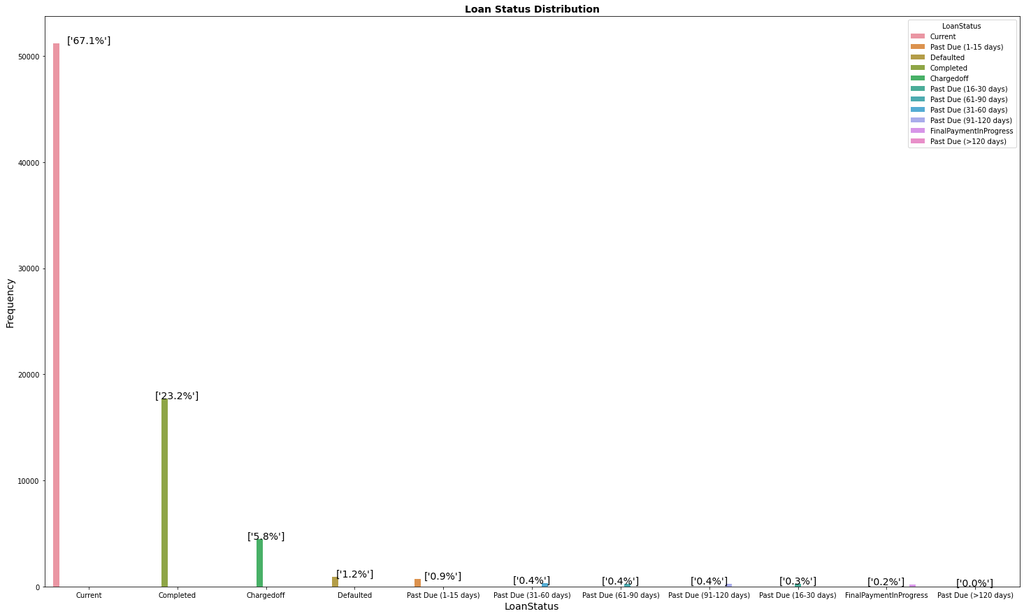

From the above distribution, 23.2% of loan have been completed and 67.1% are still pending

#### Visualizing the histogram of Loan Original Amount

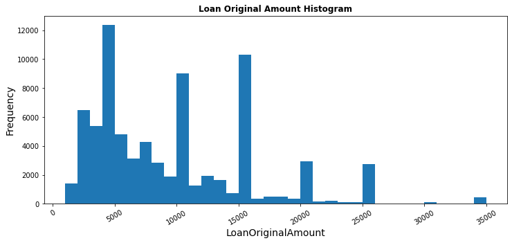

From the above histogram, we notice that people are interested in taking loans with fixed amount such as 5K, 10K, 15K,20k,25k

#### The distribution of the BorrowerAPR

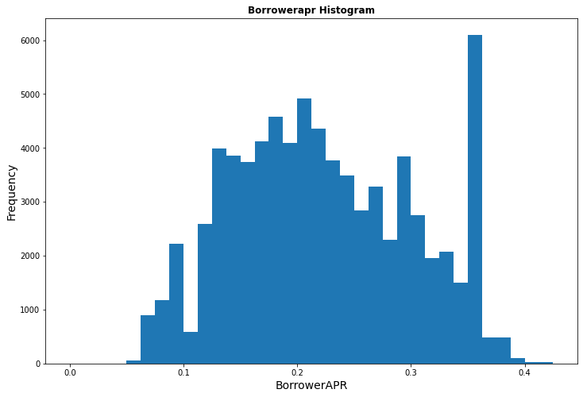

#### Distribution of ProsperRating

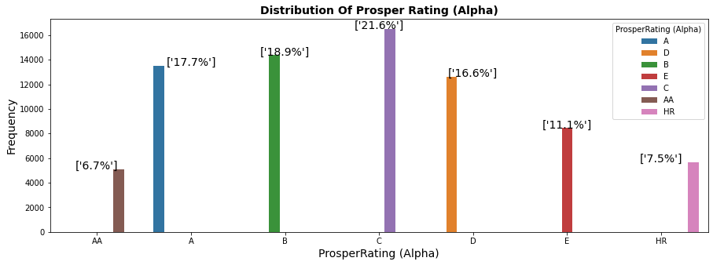

21.6 percent of loan applicants got prosper rating alpha score C

#### Distribution of ProsperScore

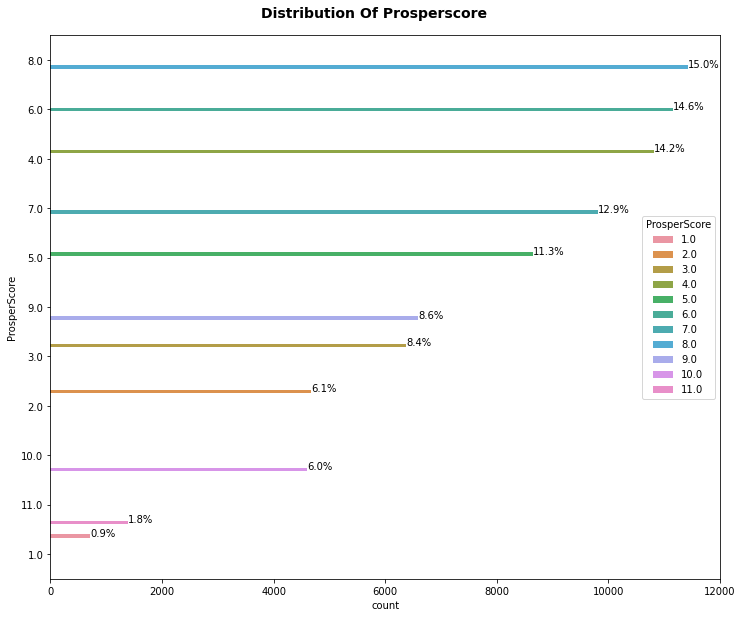

From the above plot, 15.0% of loan applicant got a prosper score 8.0 and only 1.8% of loan applicants got a prosper score of 11.0

## Visualization 2

#### Correlation between ProsperScore and BorrowerAPR

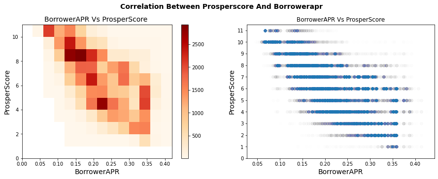

From the above plot, a lower ProsperScore leads to higher borrower rate. This shows that there is a negative relationship

#### Correlation between LoanOriginalAmount and EmploymentStatus

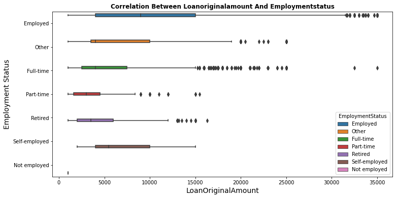

From the above plot, we notice that employed loan applicants get large fund from prosper

#### Correlation between Borrower APR and LoanStatus

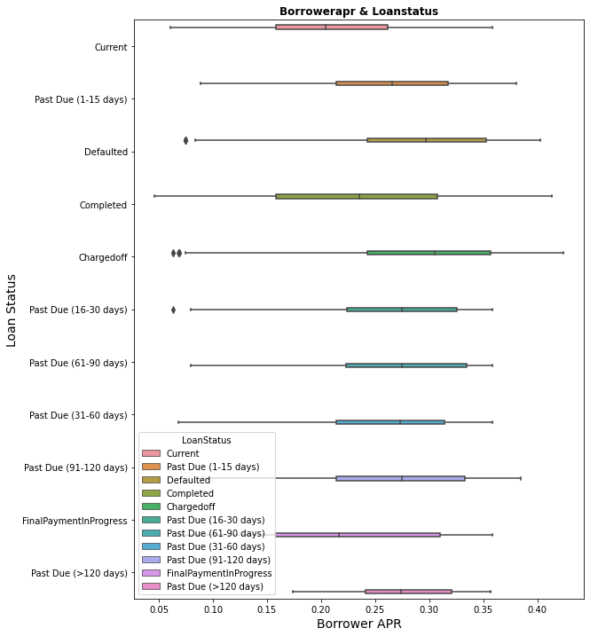

From the plot boxplot above, we notice that Current and completed loans have lower annual prosper rate than the past-due loans

## Visualization 3

#### Correlation between ProsperScore, BorrowerAPR and LoanOriginalAmount

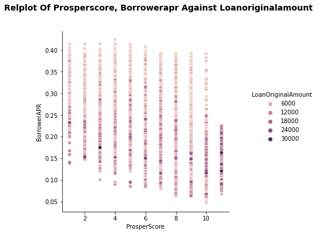

The above scatter plot shows a negative correlation between ProsperScore and BorrowAPR. Moreover, the plot reveals that most of the loan original amount greater than 20k is taken by the pool of loan applicant having prosper score between 10 and 11

#### Correlation between EmploymentStatus and ProsperScore against BorrowerAPR

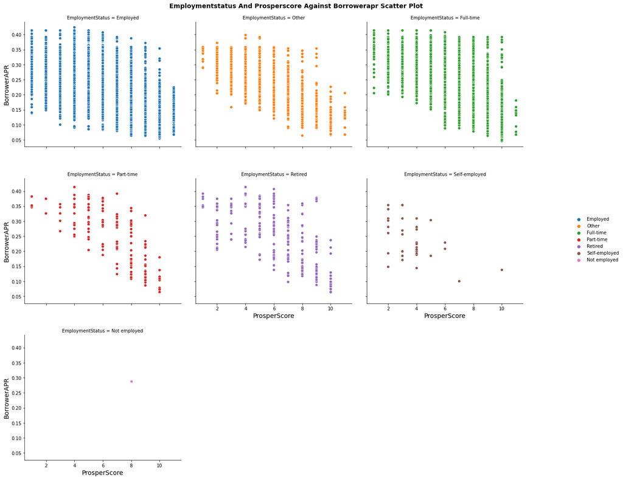

[figure not shown]

#### Correlation among LoanOriginalAmount, BorroweAPR vs LoanStatus

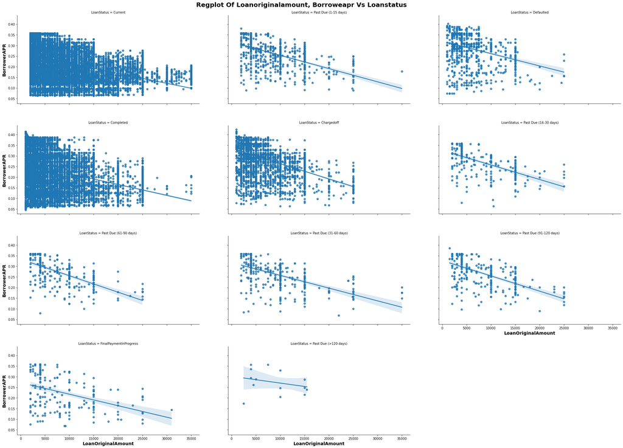

The above plot shows that BorrowerAPR, LoanOriginalAmount are negatively correlated So the higher the loan amount gets the lower the interest rate becomes.

#### Correlation between LenderYield and Borrower APR against ProsperScore

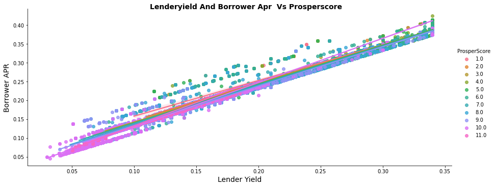

The above plot shows that there is a strong positive correlation between lender yield and BorrowerAPR Furthermore, looking at the diagonal axis, it reveals that most of loan applicants with lower BorrowerAPR and LenderYield have higher ProsperScore. Conversely, loan applicants with higher BorrowerAPR and LenderYield tend to have lower ProsperScore